# Summary of cis-eQTL mapping

Silva Kasela

5/21/2020

## Overview of cis-eQTL mapping in SPIROMICS

- Number of genes with eQTLs at FDR 5% - 4881 eGenes

| gene_type | n |
| --- | --- |
| IG_V_gene | 1 |
| IG_V_pseudogene | 1 |
| lncRNA | 891 |
| miRNA | 18 |
| misc_RNA | 11 |
| polymorphic_pseudogene | 4 |
| processed_pseudogene | 204 |
| protein_coding | 3345 |
| snoRNA | 10 |
| snRNA | 15 |
| TEC | 73 |
| TR_C_gene | 1 |
| transcribed_processed_pseudogene | 32 |
| transcribed_unitary_pseudogene | 24 |
| transcribed_unprocessed_pseudogene | 154 |
| translated_unprocessed_pseudogene | 1 |
| unitary_pseudogene | 4 |
| unprocessed_pseudogene | 92 |
| total | 4881 |

- Summary of effect size for significant eQTLs on log2 scale

```
##    Min. 1st Qu.  Median    Mean 3rd Qu.    Max.    NA's
## 0.05418 0.28830 0.54934 0.82938 1.09871 6.55263      10
```

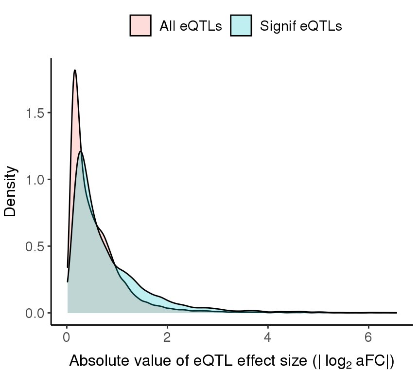

- Summary of effect size for significant eQTLs not on log2 scale

```
##      Min.   1st Qu.    Median      Mean   3rd Qu.      Max.
##  1.038267  1.221200  1.463411  1.776924  2.141637 93.872716
```

## eQTLs for COVID-19 candidate genes

Candidate genes from different sources:

- Hoffmann et al. 2020, Cell, *SARS-CoV-2 Cell Entry Depends on ACE2 and TMPRSS2 and Is Blocked by a Clinically Proven Protease Inhibitor*
- Blanco-Melo et al. 2020, Cell, *Imbalanced host response to SARS-CoV-2 drives development of COVID-19*
- Gordon et al. 2020, Nature, *A SARS-CoV-2 protein interaction map reveals targets for drug repurposing*
- Gassen et al. 2020, bioRxiv, *Analysis of SARS-CoV-2-controlled autophagy reveals spermidine, MK-2206, and niclosamide as putative antiviral therapeutics*
- Wang et al. 2020, bioRxiv, *SARS-CoV-2 invades host cells via a novel route: CD147-spike protein*
- COVID-19 Cell Atlas, https://www.covid19cellatlas.org/

Summary

- Number of unique candidate genes - **514**
- Number of genes from the candidate genes list that are expressed in the SPIROMICS samples: **496 out of 514**

```
##
##         polymorphic_pseudogene                 protein_coding
##                              1                            494
## transcribed_unitary_pseudogene                            Sum
##                              1                            496
```

```
##             gene_id gene_name                      gene_type
## 193 ENSG00000233276      GPX1         polymorphic_pseudogene
## 501 ENSG00000261040   WFDC21P transcribed_unitary_pseudogene
##                         ref
## 193      Gordon et al. 2020
## 501 Blanco-Melo et al. 2020
##                                                                     ref_title
## 193 A SARS-CoV-2 protein interaction map reveals targets for drug repurposing
## 501     Imbalanced host response to SARS-CoV-2 drives development of COVID-19
##            experimental_evidence expressed_in_spiromics is_signif_eqtl
## 193                                                   1              0
## 501 primary_cell;covid19_patient                      1              0
```

- Number of genes from the candidate genes list that are significant eGenes in the SPIROMICS samples: **108 out of 496**

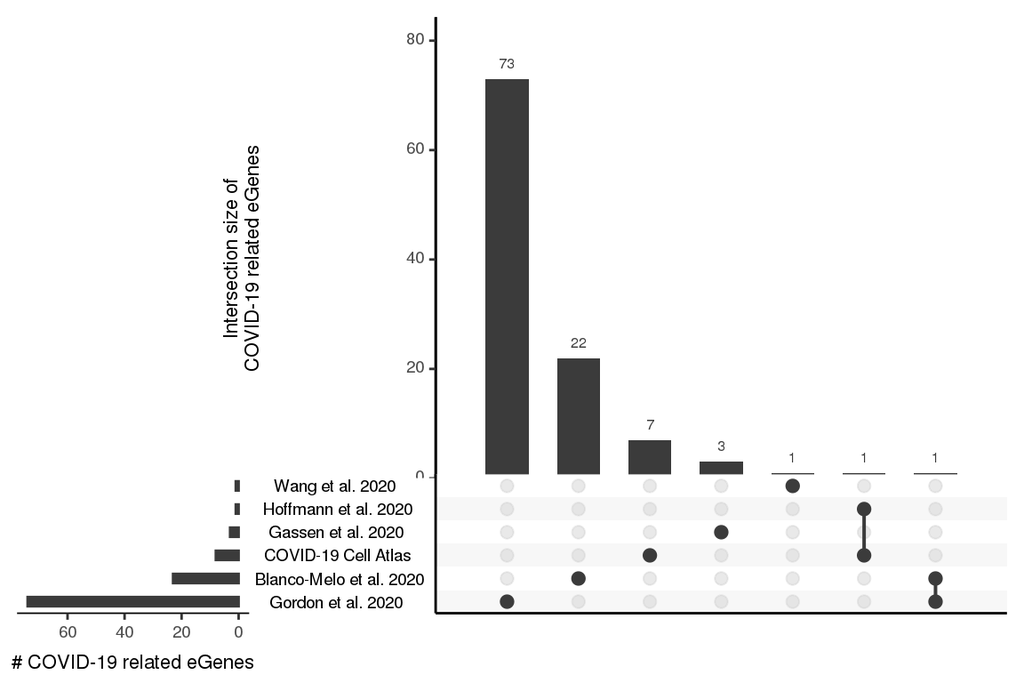

```
##    Hoffmann et al. 2020 Blanco-Melo et al. 2020      Gordon et al. 2020
##                       1                      23                      74
##      Gassen et al. 2020        Wang et al. 2020     COVID-19 Cell Atlas
##                       3                       1                       8
```

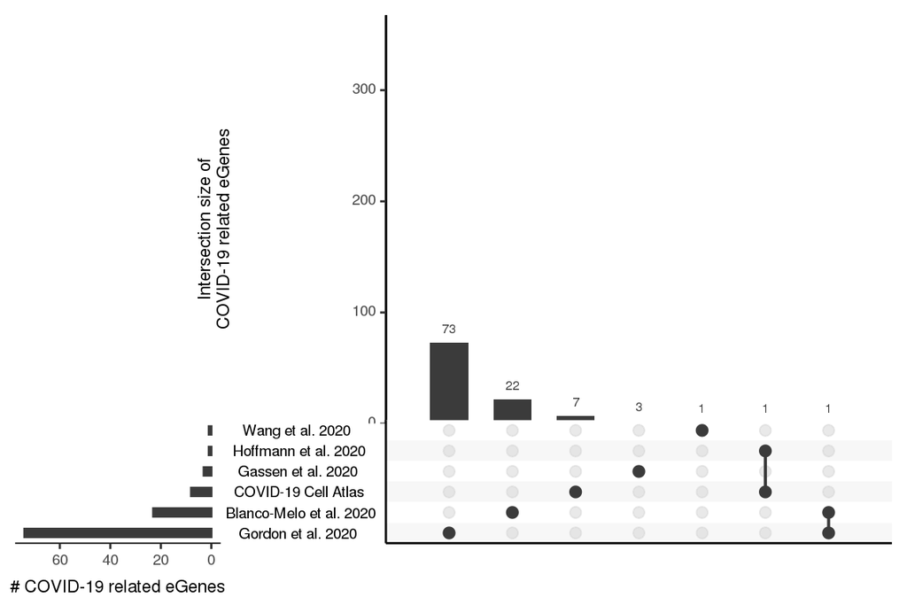

## aFC for the candidate genes

```
##               significant eGene
## Candidate gene     0     1   Sum
##            0   17457  4773 22230
##            1     388   108   496
##            Sum 17845  4881 22726
```

[figure not shown]

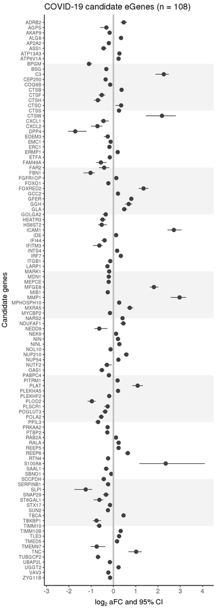

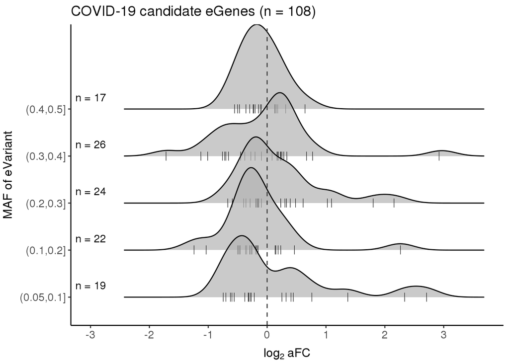

## Concordance of DE and eQTL effect size

- Ex vivo infection of primary cells (normal human bronchial epithelial (NHBE) cells)

```
##
##     Low      OK Outlier     Sum
##       2      99       7     108
```

Of the DE genes, 24 are significant candidate genes

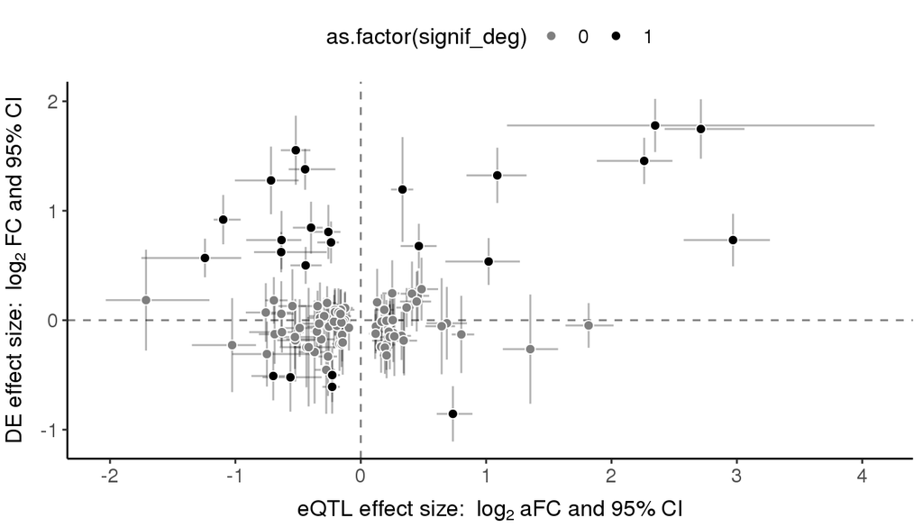

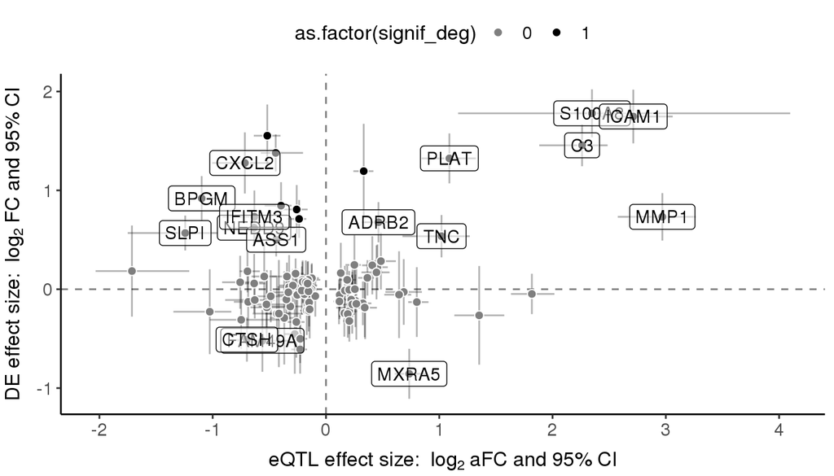

In 16 genes, the genetic regulatory effects were >50% of the magnitude of the differential expression induced by SARS-CoV-2 infection in normal human bronchial epithelial cells.

5 genes have eQTL effect size >50% larger than the DE effect size

| gene_id | gene_name | gene_type | ref | ref_title | experimental_evidence | expressed_in_spiromics | is_signif_eqtl |
| --- | --- | --- | --- | --- | --- | --- | --- |
| ENSG00000125730 | C3 | protein_coding | Blanco-Melo et al. 2020 | Imbalanced host response to SARS-CoV-2 drives development of COVID-19 | primary_cell;calu3;a549_ace2 | 1 | 1 |
| ENSG00000090339 | ICAM1 | protein_coding | Blanco-Melo et al. 2020 | Imbalanced host response to SARS-CoV-2 drives development of COVID-19 | primary_cell;calu3;a549_ace2 | 1 | 1 |
| ENSG00000196611 | MMP1 | protein_coding | Blanco-Melo et al. 2020 | Imbalanced host response to SARS-CoV-2 drives development of COVID-19 | primary_cell;covid19_patient | 1 | 1 |
| ENSG00000124107 | SLPI | protein_coding | Blanco-Melo et al. 2020 | Imbalanced host response to SARS-CoV-2 drives development of COVID-19 | primary_cell;covid19_patient | 1 | 1 |
| ENSG00000041982 | TNC | protein_coding | Blanco-Melo et al. 2020 | Imbalanced host response to SARS-CoV-2 drives development of COVID-19 | primary_cell;a549_ace2 | 1 | 1 |